# Galton’s Regression towards Mediocrity Cont’d

Alexandra Chronopoulou

Lecture 3 Example

### Statistical Inference for Simple Linear Regression

In this example, we are going to discuss Galton’s study on `Regression Towards Mediocrity in Hereditary Stature` that was published in `The Journal of the Anthropological Institute of Great Britain and Ireland` in 1886. In this study, Galton recorded the heights of parents and their children and his goal was to investigate whether it is possible to predict a child’s height based on her parents’ heights.

```r
galton <- read.table("Galton.txt", header=TRUE)

# Define the Adjusted Heigth Variable (according to Galton)
galton$AH <- galton$Height
galton$AH[galton$Gender=="F"] <- galton$Height[galton$Gender=="F"]*1.08

# Define the Mid-parental height variavle (according to Galton)
galton$MP <- (galton$Father + 1.08*galton$Mother)/2

head(galton)
```

```
##   Family Father Mother Gender Height Kids     AH    MP
## 1      1   78.5   67.0      M   73.2    4 73.200 75.43
## 2      1   78.5   67.0      F   69.2    4 74.736 75.43
## 3      1   78.5   67.0      F   69.0    4 74.520 75.43
## 4      1   78.5   67.0      F   69.0    4 74.520 75.43
## 5      2   75.5   66.5      M   73.5    4 73.500 73.66
## 6      2   75.5   66.5      M   72.5    4 72.500 73.66
```

```r
# Simple Linear Regression
slr.fit <- lm(AH ~ MP, data=galton)
summary(slr.fit)
```

```
##
## Call:
## lm(formula = AH ~ MP, data = galton)
##
## Residuals:
##     Min      1Q  Median      3Q     Max
## -9.4947 -1.4779  0.0995  1.5175  9.1262
##
## Coefficients:
##             Estimate Std. Error t value Pr(>|t|)
## (Intercept) 18.76698    2.84062   6.607 6.74e-11 ***
## MP           0.72906    0.04102  17.772  < 2e-16 ***
## ---
## Signif. codes:  0 '***' 0.001 '**' 0.01 '*' 0.05 '.' 0.1 ' ' 1
##
## Residual standard error: 2.233 on 896 degrees of freedom
## Multiple R-squared:  0.2606, Adjusted R-squared:  0.2598
## F-statistic: 315.9 on 1 and 896 DF,  p-value: < 2.2e-16
```

1. Can we say that the regression line has a good fit to the data?

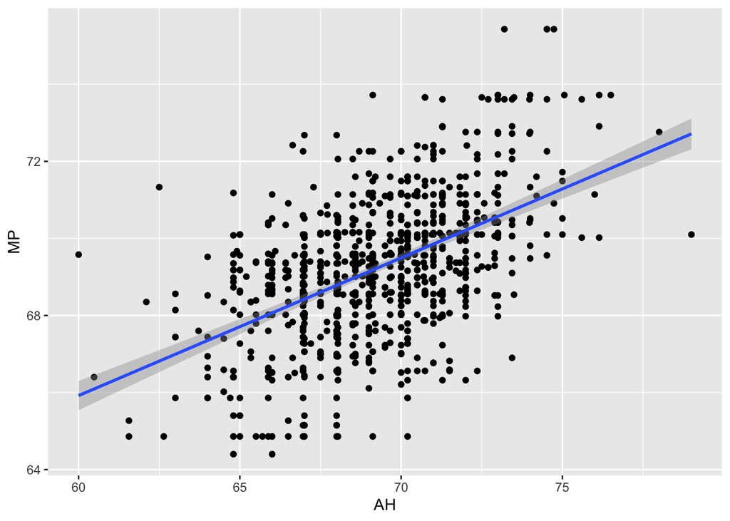

   ```r
   library(ggplot2)
   ggplot(galton, aes(AH, MP)) + geom_point() + geom_smooth(method=lm)
   ```

   The line does not have a very good fit to the data, since there is a lot of variation of the data about the estimated regression line.
2. By how much relatively is the total variation in the children’s `AH` *reduced* when the `MP` height is introduced into the analysis? Is this a relatively small or large reduction?

   The total variation in the children’s `AH` when the `MP` height is introduced into the analysis is measured by $R^2$. In this example, the $R^2$ is approximately 26% which is a relatively *low* reduction.

   ```r
   summary(slr.fit)$r.square
   ```

   ```
   ## [1] 0.2606355
   ```

   ```r
   galton.coef = summary(slr.fit)$coef
   galton.coef
   ```

   ```
   ##               Estimate Std. Error   t value     Pr(>|t|)
   ## (Intercept) 18.7669821 2.84062068  6.606648 6.735528e-11
   ## MP           0.7290562 0.04102226 17.772211 9.224505e-61
   ```

4. How do we interpret the slope coefficient *in the context of the problem*?

   The difference in the Adjusted children’s Heights (AH) for two children whose Mid-parental Heights (MP) differ by 1 inch (this is our unit here) is estimated to be 0.7.
5. How do we interpret the intercept *in the context of the problem*?

   In this example, the intercept does not have a meaningful interpretation.
6. How can we test whether or not there is a linear association between `MP` and `AH`? In other words, is the `MP` variable statistically significant?

   To answer these questions, the hypothesis we want to test is formulated as follows:
   $$\begin{cases}
   &H_0: \beta_1=0\\
   &H_{\alpha}: \beta_1 \neq 0
   \end{cases}$$
   In the lectures, we introduced a $t$-test statistic to test this hypothesis. Here, we can find the information related to this test in the R output. Specifically, the test statistic value is $t$=17.772 and the corresponding $p$-value $< 2 e-16$ which implies that we reject the null and conclude that the coefficient is statistically significant.

   We can also compute the $p$-values *manually*: For the slope:

   ```r
   2*pt(-galton.coef[2,1]/galton.coef[2,2], 896)
   ```

   ```
   ## [1] 9.224505e-61
   ```

   where `896` are the degrees of freedom associated with the residuals. Indeed,

   ```r
   slr.fit$df
   ```

   ```
   ## [1] 896
   ```

   In the lecture, we also discussed that we can test this hypothesis using an $F$ test. The results of this $F$ test are shown at the bottom of the `lm` output. We can also obtain the full ANOVA table as follows:

   ```r
   galton.anova = anova(slr.fit)
   galton.anova
   ```

   ```
   ## Analysis of Variance Table
   ##
   ## Response: AH
   ##            Df Sum Sq Mean Sq F value    Pr(>F)
   ## MP          1 1575.4 1575.38  315.85 < 2.2e-16 ***
   ## Residuals 896 4469.0    4.99
   ## ---
   ## Signif. codes:  0 '***' 0.001 '**' 0.01 '*' 0.05 '.' 0.1 ' ' 1
   ```

   We can see that the $p$-value of the $F$ test is exactly the same as the one obtained in the regression table from the $t$ test for the slope. We can also verify that the *square of the $t$ test statistic is equal to the $F$ test statistic*. Indeed,

   ```r
   galton.anova[1,4]   ## F- value from ANOVA Table
   ```

   ```
   ## [1] 315.8515
   ```

   ```r
   galton.coef[2,3]^2  ## Square of t test
   ```

   ```
   ## [1] 315.8515
   ```

   *R Remark:* Observe that the anova output can be treated as a `data.frame`. So, all the information can be extracted in the same way that we extract information from a `data.frame`.
7. What is the predicted `Adjusted Height` for a Child with parents with `Mid-parental Height` equal to 70?

   As we discussed, the *point estimate* is obtained by plugging in the “x” value to the fitted regression line. (You can also check this “by hand”.)

   ```r
   predict(slr.fit, newdata=data.frame(MP=70))
   ```

   ```
   ##        1
   ## 69.80092
   ```

   If we want to obtain a 95% confidence interval we write:

   ```r
   predict(slr.fit, newdata=data.frame(MP = 70), interval="confidence")
   ```

   ```
   ##        fit     lwr      upr
   ## 1 69.80092 69.6418 69.96003
   ```

   On the other hand, if we want to obtain a 95% prediction interval we write:

   ```r
   predict(slr.fit, newdata=data.frame(MP = 70), interval="prediction")
   ```

   ```
   ##        fit      lwr      upr
   ## 1 69.80092 65.41487 74.18696
   ```